# Intervalos de confianza y otras estadisticas

mediante Simulacion Monte Carlo

2024-12-03

Al trabajar con datos reales, ya no conoceremos los valores verdaderos de $\theta$ bajo el modelo. Por ello nos detuvimos tanto en la parte de estimacion de parametros, para asegurar que habiamos llegado a un algoritmo de Simulated Annealing confiable

El esquema con el que vamos a abordar el problema sera:

1. ```
   Importar el conjunto de datos con el que trabajaremos en el modelo de Vasicek
   ```

2. ```
   Estimar los parametros
   ```

3. ```
   Simular m trayectorias del modelo *(con los parametros estimados)*
   ```

4. ```
   Comparar visualmente con la trayectoria real observada de los datos, buscando alguna señal de que el ajuste no fue bueno.
   ```

5. ```
   Hacer inferencia sobre la muestra de trayectorias simuladas para predecir el comportamiento futuro de los datos asi como para valuar bonos u otros activos financieros que dependan de tasas de interes
   ```

## Intervalos de Confianza y otras estadisticas mediante Simulacion Monte Carlo

Cuando tengamos m trayectorias, las siguientes son un conjunto de estadisticas estandar que seria util conocer:

- Intervalo de confianza a un nivel de significancia $s$
- Intervalo de confianza a un nivel de significancia $2s$
- Intervalo de confianza a un nivel de significancia $3s$
- Media o Mediana

Probemos para estas 60 trayectorias con $t_f = 60$, $dt=0.5$, $r_0=0.1$, $\theta = (0.5,0.2,0.08)$

Con un nivel de significancia de 0.05, los intervalos de confianza calculados son al 95%, 90% y 85% de confianza respectivamente. *(en lo sucesivo se trabajara con este nivel de significancia, aunque se puede mover libremente en el codigo)*

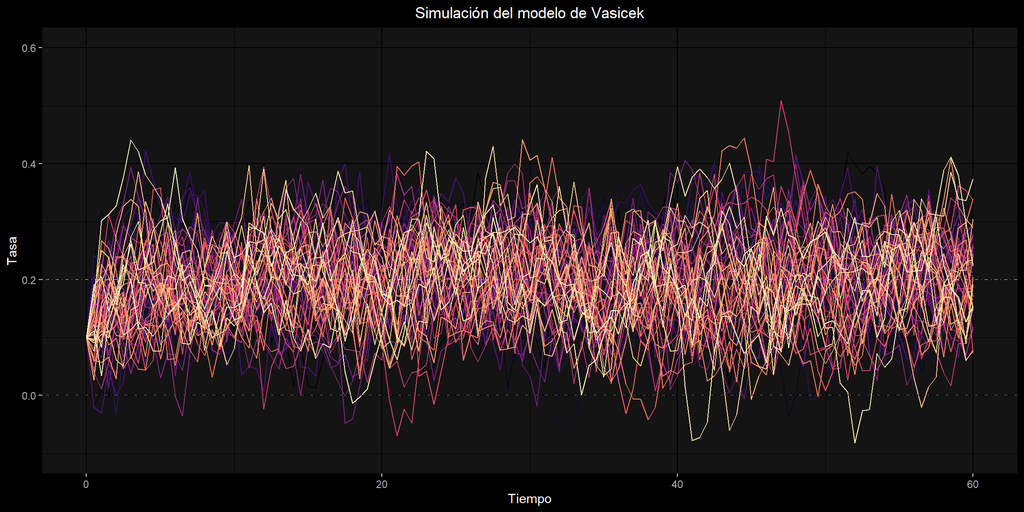

Su intervalo de confianza, media y mediana se ven:

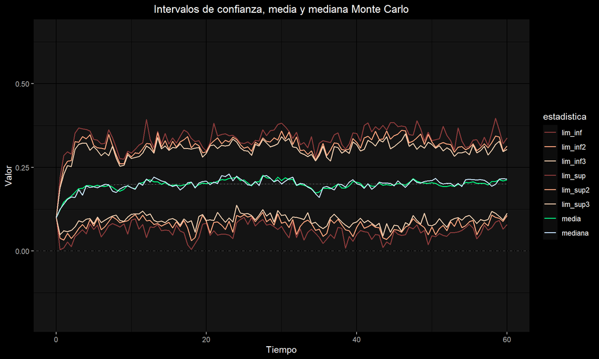

Probemos con otros datos y **muchas mas trayectorias**, ahora que sean 400 y $t_f = 90$, $dt=0.5$, $r_0=0.222$, $\theta = (0.3,0.16,0.06)$

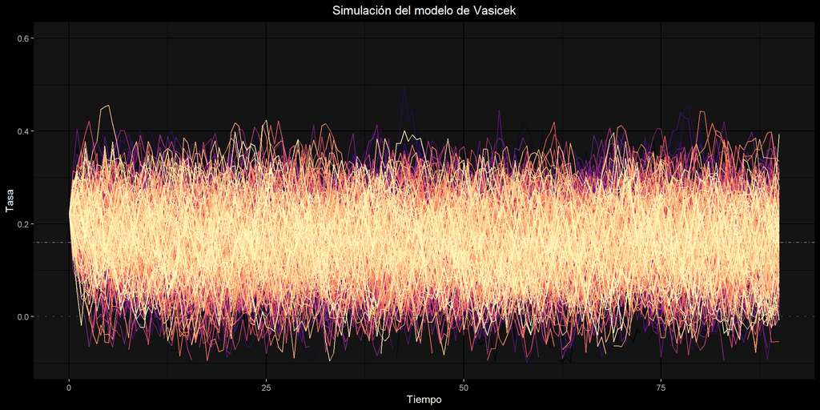

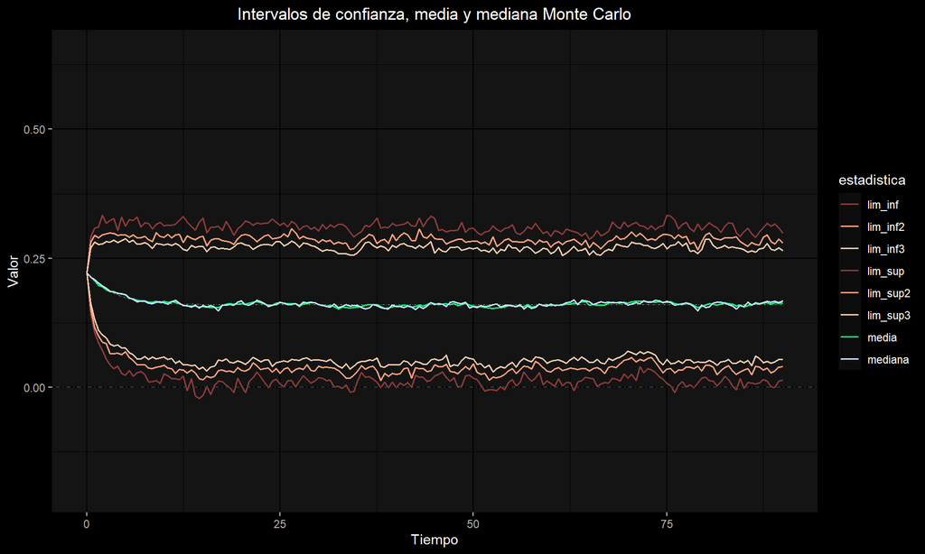

Mantengamos los parametros de simulacion pero disminuyamos el tamaño de paso a $\Delta t = \frac{1}{8}$

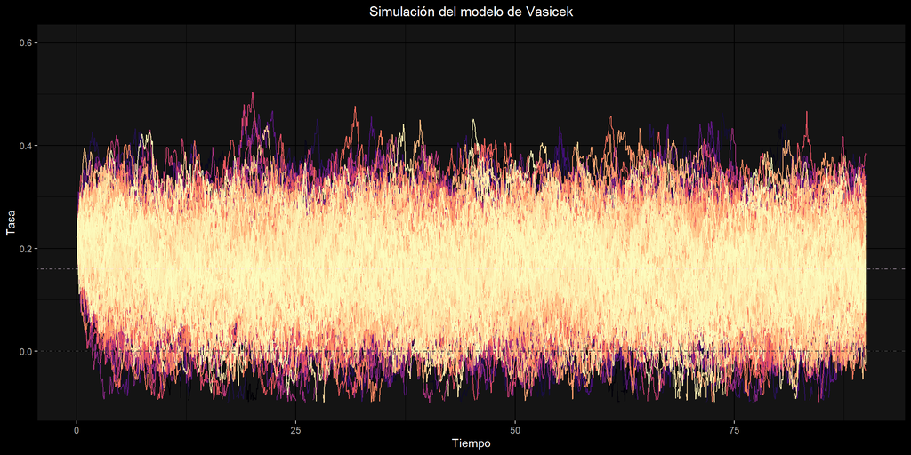

Observese que son muchas simulaciones

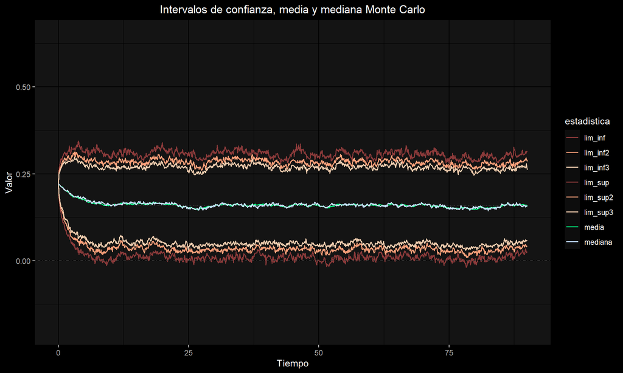

- $t_f = 90$,
- $m = 500$,
- $\Delta t = \frac{1}{24}$,
- $r_0 = 0.1$,
- $\theta \, = \, (\, \alpha, \, r_e, \, \sigma\, ) \, = \, (\, 0.20,\,0.25,\,0.05\,)$

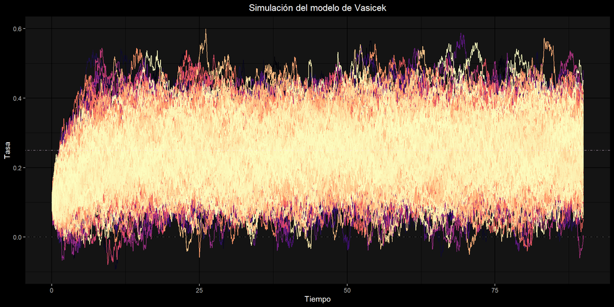

*Se ve impresionante, parece una descarga electrica*. Los intervalos de confianza y media de ese conjunto de trayectorias es:

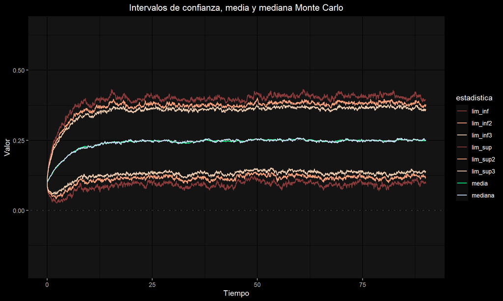

Se aprecia una convergencia clara a la esperanza teorica presentada al final de la seccion anterior